# Praktikum Pemrosesan Citra Digital - Pertemuan 3

**Nama:** Dika Aprilio Wibowo  
**NIM:** J0403241096  
**Pertemuan:** 3 - Operasi Titik dan Operasi Ketetanggaan  
**Repository:** `dikaprilio/pemrosesan-citra`

## Info Tugas

| No | Tugas |
| --- | --- |
| 1 | **Thresholding**: terapkan 3 nilai T berbeda (80, 128, 180), amati perubahan hasil segmentasi. |
| 2 | **Citra Negatif**: buat citra negatif, bandingkan histogram sebelum vs sesudah. |
| 3 | **Brightening**: uji dengan `b` positif dan `b` negatif, amati efek *clipping* pada nilai ekstrem. |
| 4 | **Smoothing**: bandingkan *mean filter* kernel 3x3 vs 5x5 pada citra ber-noise. |
| 5 | **Sharpening**: terapkan kernel Laplacian, bandingkan ketajaman tepi dengan citra asli. |

### Pengelompokan operasi

Lima tugas di atas sebenarnya terbagi dua kelompok yang cara kerjanya berbeda:

- **Operasi titik** (*pointwise*) - Tugas 1, 2, 3. Nilai piksel keluaran hanya bergantung pada nilai piksel itu sendiri: `s = T(r)`. Posisi dan tetangga tidak berpengaruh sama sekali, sehingga operasi ini bisa diwakili sepenuhnya oleh sebuah *kurva transformasi*.
- **Operasi ketetanggaan** (*neighborhood* / konvolusi) - Tugas 4, 5. Nilai piksel keluaran dihitung dari piksel itu **dan tetangganya** dalam sebuah jendela kernel. Di sinilah informasi spasial ikut dipakai, sehingga operasi ini bisa mengaburkan maupun menajamkan.

> **Citra yang dipakai:** hasil *crop* objek utama (wajah kucing) dari Pertemuan 2, dikonversi ke grayscale. Memakai citra yang sama membuat hasil kedua pertemuan langsung bisa dibandingkan.

## 0. Persiapan: Import Library dan Muat Citra Grayscale

```python
import os
import glob

import numpy as np
import cv2
import matplotlib.pyplot as plt
from numpy.lib.stride_tricks import sliding_window_view

# tampilan matplotlib
plt.rcParams["figure.dpi"] = 110
plt.rcParams["image.interpolation"] = "nearest"

IMAGE_DIR  = "../images"
OUTPUT_DIR = "output"
os.makedirs(OUTPUT_DIR, exist_ok=True)

# generator acak dengan seed tetap supaya noise pada Tugas 4 selalu sama
rng = np.random.default_rng(42)

print("numpy      :", np.__version__)
print("OpenCV     :", cv2.__version__)
print("matplotlib :", plt.matplotlib.__version__)
```

```
numpy      : 2.5.2
OpenCV     : 5.0.0
matplotlib : 3.11.1
```

### Menyiapkan citra kerja

Citra sumber dibaca langsung sebagai grayscale (`cv2.IMREAD_GRAYSCALE`), lalu:

1. **Di-crop** ke objek utama memakai ROI yang sama dengan Pertemuan 2, supaya latar belakang yang tidak relevan tidak ikut mempengaruhi histogram.
2. **Diperkecil** hingga sisi terpanjang 720 px. Ini murni alasan praktis: ukuran asli 2400 px membuat setiap gambar pada notebook jadi berat tanpa menambah informasi apa pun untuk analisis di bawah.

Hasilnya disebut `gray` dan menjadi **citra acuan** untuk kelima tugas.

```python
def cari_citra(folder=IMAGE_DIR):
    # ambil path file citra pertama di dalam folder
    ekstensi = ("*.jpg", "*.jpeg", "*.png", "*.bmp", "*.webp", "*.tif", "*.tiff")
    berkas = []
    for pola in ekstensi:
        berkas += glob.glob(os.path.join(folder, pola))
        berkas += glob.glob(os.path.join(folder, pola.upper()))
    berkas = sorted(set(berkas))
    if not berkas:
        raise FileNotFoundError(
            f"Tidak ada file citra di folder '{folder}/'. "
            "Salin foto ke folder tersebut, lalu jalankan ulang sel ini."
        )
    return berkas[0]


PATH_CITRA = cari_citra()
SISI_MAKS  = 720

# ROI objek utama, rasio (x1, y1, x2, y2) - sama dengan Pertemuan 2
ROI = (0.00, 0.49, 0.74, 0.93)

asli = cv2.imread(PATH_CITRA, cv2.IMREAD_GRAYSCALE)
if asli is None:
    raise IOError(f"Gagal membaca '{PATH_CITRA}'. Pastikan file tidak rusak.")

H0, W0 = asli.shape
x1, y1 = int(ROI[0] * W0), int(ROI[1] * H0)
x2, y2 = int(ROI[2] * W0), int(ROI[3] * H0)
crop = asli[y1:y2, x1:x2]

skala = SISI_MAKS / max(crop.shape)
gray  = cv2.resize(crop,
                   (int(crop.shape[1] * skala), int(crop.shape[0] * skala)),
                   interpolation=cv2.INTER_AREA)

TINGGI, LEBAR = gray.shape
print(f"Berkas sumber   : {PATH_CITRA}")
print(f"Ukuran asli     : {W0} x {H0} px")
print(f"Setelah crop    : {crop.shape[1]} x {crop.shape[0]} px")
print(f"Citra kerja     : {LEBAR} x {TINGGI} px  (dtype {gray.dtype})")
print(f"Rentang nilai   : {gray.min()} - {gray.max()}")
print(f"Rata-rata / std : {gray.mean():.2f} / {gray.std():.2f}")
```

```
Berkas sumber   : ../images/foto_kucing.jpg
Ukuran asli     : 1080 x 2400 px
Setelah crop    : 799 x 1056 px
Citra kerja     : 544 x 720 px  (dtype uint8)
Rentang nilai   : 2 - 225
Rata-rata / std : 94.61 / 45.85
```

### Citra acuan dan histogramnya

Histogram adalah alat baca utama sepanjang notebook ini: hampir semua efek dari kelima operasi lebih mudah dijelaskan lewat perubahan bentuk histogram daripada lewat gambarnya saja.

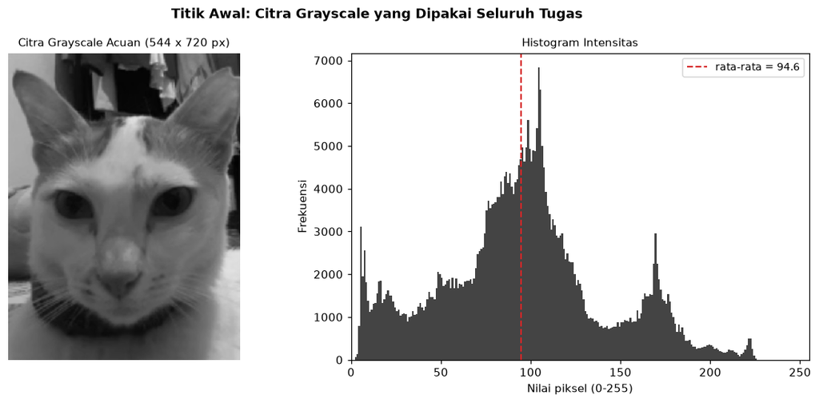

```
Tersimpan: output/00_grayscale_acuan.jpg
```

```python
fig, ax = plt.subplots(1, 2, figsize=(11, 5), gridspec_kw={"width_ratios": [1, 1.25]})

ax[0].imshow(gray, cmap="gray", vmin=0, vmax=255)
ax[0].set_title(f"Citra Grayscale Acuan ({LEBAR} x {TINGGI} px)", fontsize=10)
ax[0].axis("off")

ax[1].hist(gray.ravel(), bins=256, range=(0, 256), color="#444444")
ax[1].axvline(gray.mean(), color="tab:red", linestyle="--", linewidth=1.4,
              label=f"rata-rata = {gray.mean():.1f}")
ax[1].set_title("Histogram Intensitas", fontsize=10)
ax[1].set_xlabel("Nilai piksel (0-255)")
ax[1].set_ylabel("Frekuensi")
ax[1].set_xlim(0, 255)
ax[1].legend(fontsize=9)

plt.suptitle("Titik Awal: Citra Grayscale yang Dipakai Seluruh Tugas",
             fontsize=12, fontweight="bold")
plt.tight_layout()
plt.show()

cv2.imwrite(os.path.join(OUTPUT_DIR, "00_grayscale_acuan.jpg"), gray)
print("Tersimpan: output/00_grayscale_acuan.jpg")
```

### Fungsi bantu

Empat fungsi kecil dipakai berulang kali di bawah, dikumpulkan di sini supaya sel-sel berikutnya tetap ringkas:

| Fungsi | Kegunaan |
| --- | --- |
| `tampilkan(...)` | Menyusun beberapa citra menjadi satu grid subplot |
| `histogram(...)` | Menumpuk beberapa histogram pada satu sumbu |
| `metrik(...)` | Menghitung MAE dan PSNR antara dua citra |
| `potong(...)` | Mengambil area zoom yang sama untuk semua perbandingan detail |

```python
# area zoom untuk perbandingan detail (rasio x1, y1, x2, y2) - sekitar mata kucing
ZOOM = (0.18, 0.40, 0.78, 0.62)
ZX1, ZY1 = int(ZOOM[0] * LEBAR), int(ZOOM[1] * TINGGI)
ZX2, ZY2 = int(ZOOM[2] * LEBAR), int(ZOOM[3] * TINGGI)


def potong(img):
    # ambil area ZOOM yang sama untuk semua citra
    return img[ZY1:ZY2, ZX1:ZX2]


def tampilkan(item, judul_utama, ncols=3, lebar_kolom=3.3, cmap="gray",
              vmin=0, vmax=255):
    # item = list of (array, judul); disusun jadi grid subplot
    n = len(item)
    ncols = min(ncols, n)
    nrows = int(np.ceil(n / ncols))
    rasio = item[0][0].shape[0] / item[0][0].shape[1]   # tinggi / lebar
    fig, ax = plt.subplots(nrows, ncols,
                           figsize=(lebar_kolom * ncols,
                                    lebar_kolom * rasio * nrows + 0.55 * nrows))
    ax = np.atleast_1d(ax).ravel()
    for a, (arr, judul) in zip(ax, item):
        a.imshow(arr, cmap=cmap, vmin=vmin, vmax=vmax)
        a.set_title(judul, fontsize=9.5)
        a.axis("off")
    for a in ax[n:]:
        a.axis("off")
    # sisakan ruang tetap di atas supaya judul utama tidak bertabrakan
    # dengan judul subplot yang kadang terdiri dari dua baris
    tinggi = fig.get_size_inches()[1]
    plt.suptitle(judul_utama, fontsize=12, fontweight="bold",
                 y=1 - 0.08 / tinggi, va="top")
    plt.tight_layout(rect=[0, 0, 1, 1 - 0.45 / tinggi])
    plt.show()


def histogram(item, judul, ax=None, alpha=0.55, log=False):
    # item = list of (array, label, warna)
    mandiri = ax is None
    if mandiri:
        fig, ax = plt.subplots(figsize=(10, 3.8))
    for arr, label, warna in item:
        ax.hist(arr.ravel(), bins=256, range=(0, 256),
                alpha=alpha, label=label, color=warna)
    if log:
        ax.set_yscale("log")
    ax.set_title(judul, fontsize=10)
    ax.set_xlabel("Nilai piksel (0-255)")
    ax.set_ylabel("Frekuensi" + (" (skala log)" if log else ""))
    ax.set_xlim(0, 255)
    ax.legend(fontsize=9)
    if mandiri:
        plt.tight_layout()
        plt.show()


def metrik(a, b):
    # MAE dan PSNR antara dua citra grayscale
    a_f, b_f = a.astype(np.float64), b.astype(np.float64)
    mae = np.abs(a_f - b_f).mean()
    mse = ((a_f - b_f) ** 2).mean()
    psnr = float("inf") if mse == 0 else 10 * np.log10(255.0 ** 2 / mse)
    return mae, psnr


print(f"Area zoom: ({ZX1}, {ZY1}) -> ({ZX2}, {ZY2})  = {ZX2-ZX1} x {ZY2-ZY1} px")
```

```
Area zoom: (97, 288) -> (424, 446)  = 327 x 158 px
```

## Tugas 1: Thresholding dengan 3 Nilai T

### Dasar teori

*Thresholding* adalah operasi titik paling sederhana: setiap piksel dibandingkan dengan satu ambang `T`, lalu dipaksa menjadi salah satu dari dua nilai.

```
        { 255   jika r >= T   (objek / foreground)
s(r) =  {
        {   0   jika r <  T   (latar / background)
```

Hasilnya adalah **citra biner**: 256 tingkat keabuan diringkas jadi 2 nilai saja. Seluruh informasi gradasi hilang, yang tersisa hanya keputusan "terang atau gelap". Karena itu thresholding dipakai sebagai langkah **segmentasi** - memisahkan objek dari latar - bukan sebagai perbaikan kualitas.

Nilai `T` menentukan di mana garis pemisah itu ditarik pada histogram. Semua piksel di sebelah kiri `T` menjadi hitam, semua yang di kanan menjadi putih. Menaikkan `T` berarti menaikkan syarat untuk disebut "objek", sehingga area putih menyusut.

```python
def threshold_manual(img, T):
    # implementasi manual: perbandingan elemen demi elemen, tanpa fungsi bawaan
    return np.where(img >= T, 255, 0).astype(np.uint8)


NILAI_T = [80, 128, 180]
biner = {T: threshold_manual(gray, T) for T in NILAI_T}

# verifikasi terhadap fungsi bawaan OpenCV
print("Verifikasi manual vs cv2.threshold(THRESH_BINARY)\n")
for T in NILAI_T:
    # cv2 memakai r > T, manual memakai r >= T -> pakai T-1 agar setara
    _, biner_cv2 = cv2.threshold(gray, T - 1, 255, cv2.THRESH_BINARY)
    identik = np.array_equal(biner[T], biner_cv2)
    print(f"  T = {T:3d}  ->  identik: {identik}")
```

```
Verifikasi manual vs cv2.threshold(THRESH_BINARY)

  T =  80  ->  identik: True
  T = 128  ->  identik: True
  T = 180  ->  identik: True
```

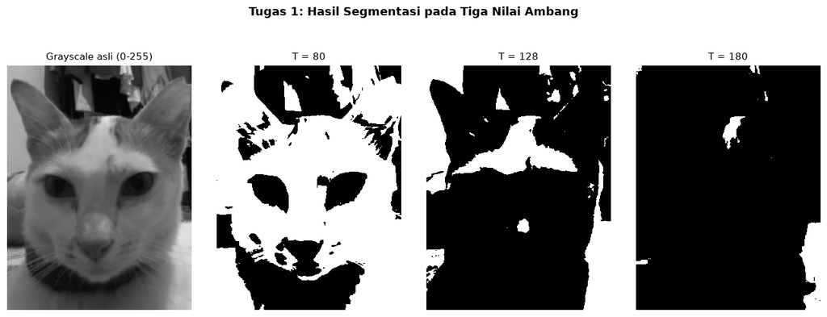

```python
item = [(gray, f"Grayscale asli (0-255)")]
item += [(biner[T], f"T = {T}") for T in NILAI_T]
tampilkan(item, "Tugas 1: Hasil Segmentasi pada Tiga Nilai Ambang", ncols=4,
          lebar_kolom=3.0)
```

### Membaca hasilnya lewat histogram

Cara paling jelas untuk memahami kenapa ketiga hasil di atas berbeda adalah menggambar posisi ketiga `T` langsung di atas histogram citra asli. Luas histogram di kanan garis = proporsi piksel yang menjadi putih.

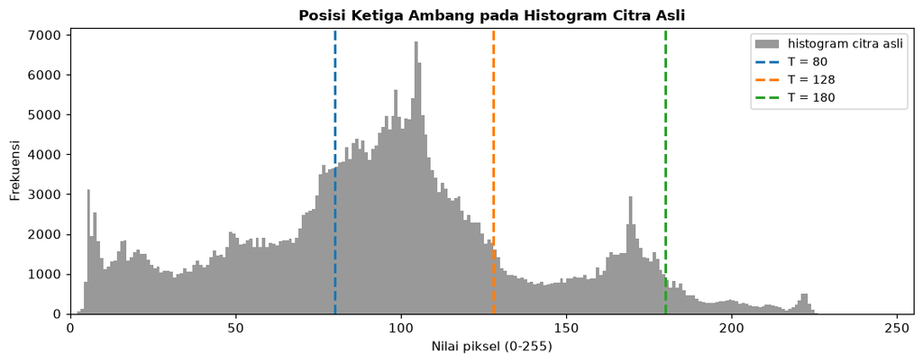

```
    T   Piksel putih    % putih    % hitam
------------------------------------------
   80        258,581      66.0%      34.0%
  128         75,323      19.2%      80.8%
  180         14,851       3.8%      96.2%
```

```python
fig, ax = plt.subplots(figsize=(10, 4))
ax.hist(gray.ravel(), bins=256, range=(0, 256), color="#999999", label="histogram citra asli")

warna_T = {80: "tab:blue", 128: "tab:orange", 180: "tab:green"}
for T in NILAI_T:
    ax.axvline(T, color=warna_T[T], linestyle="--", linewidth=2, label=f"T = {T}")

ax.set_title("Posisi Ketiga Ambang pada Histogram Citra Asli", fontsize=11,
             fontweight="bold")
ax.set_xlabel("Nilai piksel (0-255)")
ax.set_ylabel("Frekuensi")
ax.set_xlim(0, 255)
ax.legend(fontsize=9)
plt.tight_layout()
plt.show()

print(f"{'T':>5}{'Piksel putih':>15}{'% putih':>11}{'% hitam':>11}")
print("-" * 42)
for T in NILAI_T:
    putih = int((biner[T] == 255).sum())
    persen = putih / gray.size * 100
    print(f"{T:>5}{putih:>15,}{persen:>10.1f}%{100 - persen:>10.1f}%")
```

### Pembanding: ambang otomatis (metode Otsu)

Ketiga nilai `T` di atas dipilih manual. Sebagai pembanding, metode **Otsu** mencari `T` secara otomatis dengan memaksimalkan *variansi antar-kelas* - secara praktis: mencari lembah terdalam di antara dua puncak histogram.

```
Ambang otomatis Otsu : T = 94
Piksel putih         : 50.2%
```

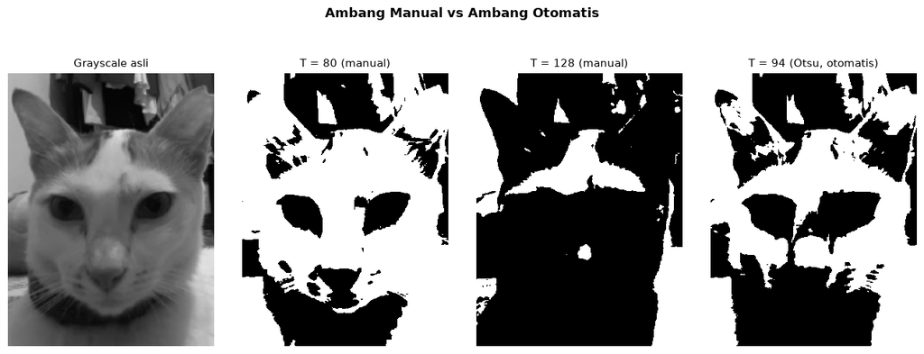

```
Tersimpan: output/01_threshold_T80.jpg, T128.jpg, T180.jpg, otsu.jpg
```

```python
T_otsu, biner_otsu = cv2.threshold(gray, 0, 255,
                                   cv2.THRESH_BINARY + cv2.THRESH_OTSU)
print(f"Ambang otomatis Otsu : T = {T_otsu:.0f}")
print(f"Piksel putih         : {(biner_otsu == 255).sum() / gray.size * 100:.1f}%")

tampilkan([(gray, "Grayscale asli"),
           (biner[80], "T = 80 (manual)"),
           (biner[128], "T = 128 (manual)"),
           (biner_otsu, f"T = {T_otsu:.0f} (Otsu, otomatis)")],
          "Ambang Manual vs Ambang Otomatis", ncols=4, lebar_kolom=3.0)

for T in NILAI_T:
    cv2.imwrite(os.path.join(OUTPUT_DIR, f"01_threshold_T{T}.jpg"), biner[T])
cv2.imwrite(os.path.join(OUTPUT_DIR, "01_threshold_otsu.jpg"), biner_otsu)
print("Tersimpan: output/01_threshold_T80.jpg, T128.jpg, T180.jpg, otsu.jpg")
```

### Kesimpulan Tugas 1

1. **`T` berbanding terbalik dengan luas area putih.** Naik dari 80 ke 128 lalu 180 membuat syarat "objek" makin ketat, dan persentase piksel putih anjlok dari 66,0% ke 19,2% lalu 3,8%. Angka-angka itu tidak lain adalah luas histogram di sebelah kanan garis ambang.
2. **T = 80 memberi segmentasi terbaik di antara ketiganya.** Wajah kucing terangkat utuh sebagai satu area putih yang terpisah jelas dari latar gelap. Kekurangannya, beberapa bagian latar yang kebetulan terang - dinding dan lantai di tepi kiri dan kanan - ikut lolos jadi putih, jadi hasilnya belum sempurna.
3. **T = 128 sudah *over-segmentation*, bukan pilihan tengah yang aman.** Meskipun 128 adalah nilai tengah rentang 0-255, pada citra ini ia jatuh jauh di sebelah kanan puncak histogram (puncak ada di 104, rata-rata 94,6). Akibatnya sebagian besar wajah kucing yang bernilai sekitar 90-120 ikut tertekan jadi hitam, dan yang tersisa tinggal dahi serta hidung yang paling terang. Bentuk objeknya sudah tidak terbaca.
4. **T = 180 - *over-segmentation* parah.** Hanya 3,8% piksel yang bertahan. Objek utama praktis lenyap dan hasilnya tidak bisa dipakai untuk apa pun.
5. **Nilai tengah rentang bukan tebakan yang baik.** `T` harus dipilih berdasarkan histogram citra yang bersangkutan, bukan dari tengah rentang 8-bit. Citra ini tergolong gelap, jadi ambang yang masuk akal juga harus rendah.
6. **Otsu membenarkan hal itu.** Ambang otomatisnya jatuh di `T = 94`, dekat dengan T = 80 yang secara visual paling baik dan jauh dari T = 128. Karena Otsu menghitung ambang dari histogram citra itu sendiri, ia jauh lebih tahan banting terhadap perbedaan pencahayaan antar citra.
7. **Thresholding merusak informasi secara permanen.** Setelah jadi biner, citra tidak bisa dikembalikan ke grayscale semula. Ini berbeda dengan Tugas 2 dan 3 yang masih bisa dibalik.

## Tugas 2: Citra Negatif

### Dasar teori

Citra negatif membalik skala keabuan: yang gelap jadi terang dan sebaliknya.

```
s(r) = (L - 1) - r  =  255 - r        (untuk citra 8-bit, L = 256)
```

Ini adalah operasi titik dengan **kurva transformasi berupa garis lurus menurun** dengan kemiringan -1. Dua sifat penting mengikuti dari situ:

- **Tidak ada informasi yang hilang.** Pemetaannya satu-ke-satu, jadi operasi ini sepenuhnya *reversible*: menegatifkan citra negatif mengembalikan citra asli persis.
- **Tidak ada clipping.** Karena `r` berada di 0-255, maka `255 - r` juga otomatis berada di 0-255. Ini kontras dengan Tugas 3, di mana penambahan konstanta bisa keluar rentang.

Kegunaan praktisnya: menonjolkan detail yang tersembunyi di area gelap, karena mata manusia lebih peka membedakan gradasi pada area terang.

```python
# ---------- implementasi manual ----------
negatif = (255 - gray.astype(np.int16)).astype(np.uint8)

# ---------- verifikasi dengan fungsi bawaan ----------
negatif_cv2 = cv2.bitwise_not(gray)          # NOT bitwise = 255 - r untuk uint8
print("Manual (255 - r) vs cv2.bitwise_not :",
      "identik" if np.array_equal(negatif, negatif_cv2) else "BERBEDA")

# ---------- bukti reversibilitas ----------
balik = (255 - negatif.astype(np.int16)).astype(np.uint8)
print("Negatif dari negatif == citra asli  :",
      "identik" if np.array_equal(balik, gray) else "BERBEDA")

print()
print(f"{'Citra':<12}{'min':>6}{'max':>6}{'rata-rata':>12}{'std':>9}")
print("-" * 45)
for nama, arr in [("Asli", gray), ("Negatif", negatif)]:
    print(f"{nama:<12}{arr.min():>6}{arr.max():>6}{arr.mean():>12.2f}{arr.std():>9.2f}")
print()
print(f"Cek teori  : 255 - rata_asli = {255 - gray.mean():.2f}  "
      f"(rata negatif = {negatif.mean():.2f})")
print(f"Std sama   : simpangan baku tidak berubah karena kemiringan kurva |-1| = 1")
```

```
Manual (255 - r) vs cv2.bitwise_not : identik
Negatif dari negatif == citra asli  : identik

Citra          min   max   rata-rata      std
---------------------------------------------
Asli             2   225       94.61    45.85
Negatif         30   253      160.39    45.85

Cek teori  : 255 - rata_asli = 160.39  (rata negatif = 160.39)
Std sama   : simpangan baku tidak berubah karena kemiringan kurva |-1| = 1
```

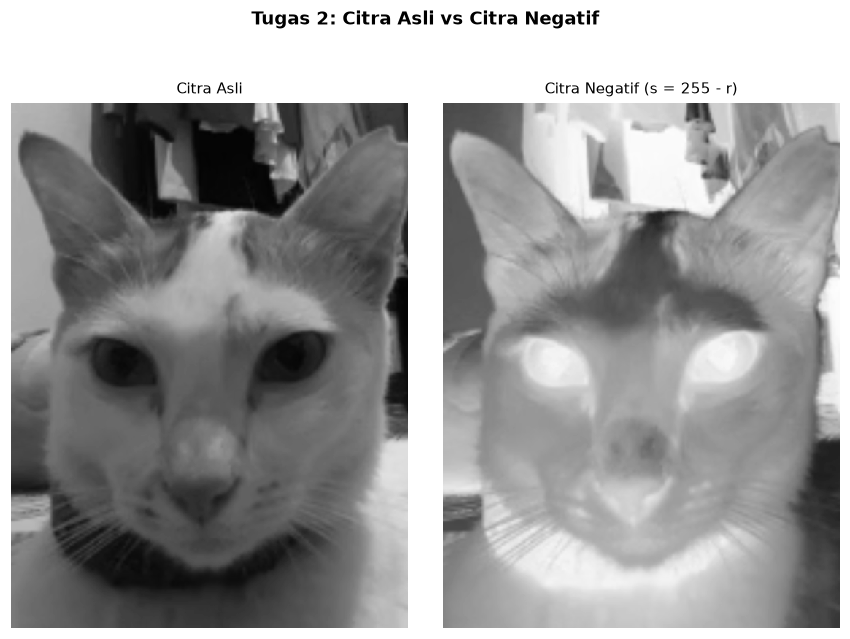

```python
tampilkan([(gray, "Citra Asli"), (negatif, "Citra Negatif (s = 255 - r)")],
          "Tugas 2: Citra Asli vs Citra Negatif", ncols=2, lebar_kolom=4.0)
```

### Perbandingan histogram sebelum vs sesudah

Inilah bagian inti tugas ini. Karena kurva transformasinya `s = 255 - r`, histogram hasil seharusnya merupakan **cerminan sempurna** histogram asli terhadap sumbu vertikal di tengah (nilai 127,5). Klaim itu diuji langsung secara numerik di bawah, bukan sekadar dilihat.

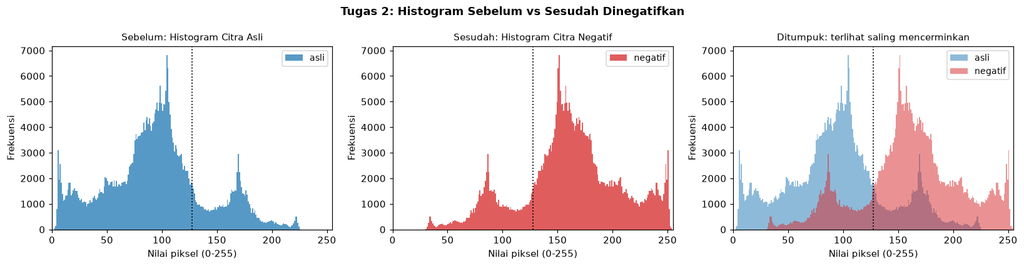

```python
fig, ax = plt.subplots(1, 3, figsize=(15, 3.9))

histogram([(gray, "asli", "tab:blue")], "Sebelum: Histogram Citra Asli",
          ax=ax[0], alpha=0.75)
histogram([(negatif, "negatif", "tab:red")], "Sesudah: Histogram Citra Negatif",
          ax=ax[1], alpha=0.75)
histogram([(gray, "asli", "tab:blue"), (negatif, "negatif", "tab:red")],
          "Ditumpuk: terlihat saling mencerminkan", ax=ax[2], alpha=0.5)

for a in ax:
    a.axvline(127.5, color="black", linestyle=":", linewidth=1.2)

plt.suptitle("Tugas 2: Histogram Sebelum vs Sesudah Dinegatifkan",
             fontsize=12, fontweight="bold")
plt.tight_layout()
plt.show()
```

```python
# uji numerik: apakah histogram negatif benar-benar cerminan histogram asli?
hist_asli    = np.bincount(gray.ravel(),    minlength=256)
hist_negatif = np.bincount(negatif.ravel(), minlength=256)

cocok = np.array_equal(hist_negatif, hist_asli[::-1])
print("hist_negatif == hist_asli dibalik urutannya :", cocok)
print(f"Selisih maksimum antar-bin                 : "
      f"{np.abs(hist_negatif - hist_asli[::-1]).max()}")
print()

# pergeseran pusat massa histogram
print(f"Puncak histogram asli    : nilai {hist_asli.argmax():3d} "
      f"({hist_asli.max():,} piksel)")
print(f"Puncak histogram negatif : nilai {hist_negatif.argmax():3d} "
      f"({hist_negatif.max():,} piksel)")
print(f"Jumlah keduanya          : {hist_asli.argmax() + hist_negatif.argmax()} "
      f"(teori: 255)")

cv2.imwrite(os.path.join(OUTPUT_DIR, "02_negatif.jpg"), negatif)
print("\nTersimpan: output/02_negatif.jpg")
```

```
hist_negatif == hist_asli dibalik urutannya : True
Selisih maksimum antar-bin                 : 0

Puncak histogram asli    : nilai 104 (6,829 piksel)
Puncak histogram negatif : nilai 151 (6,829 piksel)
Jumlah keduanya          : 255 (teori: 255)

Tersimpan: output/02_negatif.jpg
```

### Kesimpulan Tugas 2

1. **Histogram sesudah adalah cerminan tepat histogram sebelum.** Uji numerik di atas menunjukkan `hist_negatif` sama persis dengan `hist_asli` yang dibalik urutannya, selisih maksimum antar-bin = 0. Jadi bukan sekadar "mirip terbalik", tetapi identik.
2. **Bentuk distribusinya tidak berubah, hanya posisinya.** Rata-rata bergeser mengikuti `255 - rata_asli`, sementara simpangan baku tetap sama karena kemiringan kurva transformasinya bernilai mutlak 1. Artinya **kontras citra tidak berubah**, yang berubah hanya arah terang-gelapnya.
3. **Operasi ini sepenuhnya reversible.** Menegatifkan hasil negatif mengembalikan citra asli piksel demi piksel. Tidak ada informasi yang hilang, berbeda dengan thresholding di Tugas 1.
4. **Tidak terjadi clipping.** Rentang keluaran otomatis tetap 0-255 tanpa perlu `np.clip`, karena pemetaannya menukar batas bawah dan batas atas secara simetris.
5. **Manfaat praktisnya** adalah memindahkan detail dari area gelap - tempat mata manusia lemah membedakan gradasi - ke area terang, sehingga bagian bayangan pada citra jadi lebih mudah diamati.

## Tugas 3: Brightening dengan b Positif dan b Negatif

### Dasar teori

*Brightening* menambahkan konstanta `b` ke setiap piksel:

```
s(r) = r + b        b > 0  -> lebih terang
                    b < 0  -> lebih gelap
```

Kurva transformasinya garis lurus dengan kemiringan 1 yang digeser naik/turun sebesar `b`. Karena kemiringannya tetap 1, **kontras tidak berubah** - yang berubah hanya tingkat kecerahan keseluruhan.

### Masalahnya: rentang 8-bit itu terbatas

Hasil `r + b` bisa keluar dari rentang sah 0-255. Ada dua cara menanganinya, dan hanya satu yang benar:

- **Clipping (benar).** Nilai di atas 255 dipaksa jadi 255, di bawah 0 jadi 0. Informasi pada nilai ekstrem **hilang permanen** (banyak nilai berbeda dipetakan ke satu nilai yang sama), tetapi citranya tetap masuk akal.
- **Wrap-around (bug).** Kalau penjumlahan dilakukan langsung pada `uint8` tanpa dinaikkan ke tipe yang lebih besar, NumPy melakukan aritmetika modulo 256: `250 + 40` menjadi `34`, bukan `255`. Piksel paling terang tiba-tiba jadi hitam pekat. Ini kesalahan klasik yang akan dibuktikan di bawah.

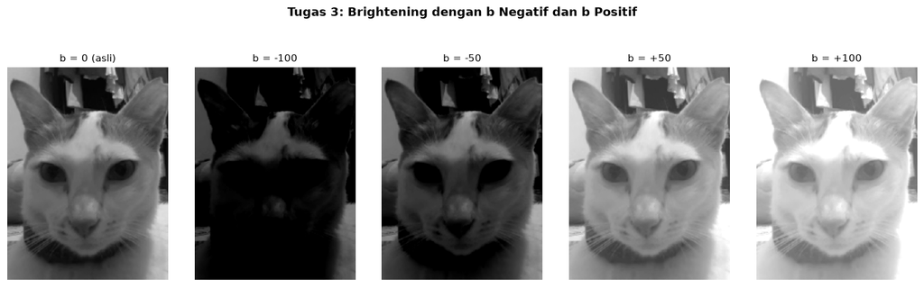

```python
def brighten(img, b):
    # naikkan ke int16 dulu supaya penjumlahan tidak overflow, baru di-clip
    return np.clip(img.astype(np.int16) + b, 0, 255).astype(np.uint8)


NILAI_B = [-100, -50, 50, 100]
terang = {b: brighten(gray, b) for b in NILAI_B}

item = [(gray, "b = 0 (asli)")]
item += [(terang[b], f"b = {b:+d}") for b in NILAI_B]
tampilkan(item, "Tugas 3: Brightening dengan b Negatif dan b Positif",
          ncols=5, lebar_kolom=2.6)
```

### Mengukur clipping secara langsung

Piksel dikatakan *ter-clip* kalau nilai idealnya `r + b` sudah keluar rentang 0-255 sehingga harus dipaksa ke batas. Jumlahnya bisa dihitung persis: untuk `b > 0`, semua piksel dengan `r > 255 - b` akan ter-clip ke 255.

```python
print(f"{'b':>6}{'rata-rata':>12}{'clip ke 0':>12}{'clip ke 255':>14}{'total clip':>13}")
print("-" * 58)

info_clip = {}
for b in [-100, -50, 0, 50, 100]:
    hasil  = brighten(gray, b)
    ideal  = gray.astype(np.int16) + b
    bawah  = int((ideal < 0).sum())
    atas   = int((ideal > 255).sum())
    total  = (bawah + atas) / gray.size * 100
    info_clip[b] = (bawah, atas, total)
    print(f"{b:>+6d}{hasil.mean():>12.2f}{bawah:>12,}{atas:>14,}{total:>12.2f}%")

print()
print("Catatan: pada b = 0 tidak ada clipping sama sekali (baris kontrol).")
print(f"Rata-rata bergeser mendekati {gray.mean():.1f} + b, tetapi tidak persis")
print("sebesar b karena piksel yang ter-clip berhenti di batas.")
```

```
     b   rata-rata   clip ke 0   clip ke 255   total clip
----------------------------------------------------------
  -100       15.01     220,202             0       56.22%
   -50       48.69      65,450             0       16.71%
    +0       94.61           0             0        0.00%
   +50      144.49           0         4,163        1.06%
  +100      191.84           0        49,756       12.70%

Catatan: pada b = 0 tidak ada clipping sama sekali (baris kontrol).
Rata-rata bergeser mendekati 94.6 + b, tetapi tidak persis
sebesar b karena piksel yang ter-clip berhenti di batas.
```

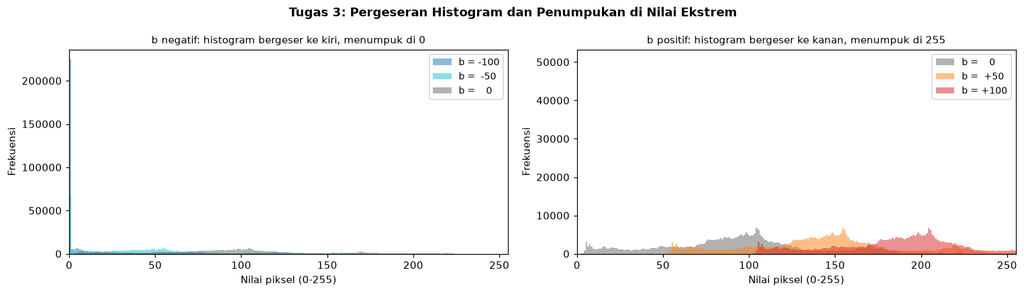

```
Tinggi bin pada nilai ekstrem (bukti penumpukan akibat clipping):

     b       bin 0     bin 255
------------------------------
  -100     224,838           0
   -50      67,358           0
    +0           0           0
   +50           0       4,368
  +100           0      50,734
```

```python
fig, ax = plt.subplots(1, 2, figsize=(14, 4))

histogram([(terang[-100], "b = -100", "tab:blue"),
           (terang[-50],  "b =  -50", "tab:cyan"),
           (gray,         "b =    0", "#666666")],
          "b negatif: histogram bergeser ke kiri, menumpuk di 0", ax=ax[0], alpha=0.5)

histogram([(gray,        "b =    0", "#666666"),
           (terang[50],  "b =  +50", "tab:orange"),
           (terang[100], "b = +100", "tab:red")],
          "b positif: histogram bergeser ke kanan, menumpuk di 255", ax=ax[1], alpha=0.5)

plt.suptitle("Tugas 3: Pergeseran Histogram dan Penumpukan di Nilai Ekstrem",
             fontsize=12, fontweight="bold")
plt.tight_layout()
plt.show()

print("Tinggi bin pada nilai ekstrem (bukti penumpukan akibat clipping):\n")
print(f"{'b':>6}{'bin 0':>12}{'bin 255':>12}")
print("-" * 30)
for b in [-100, -50, 0, 50, 100]:
    h = np.bincount(brighten(gray, b).ravel(), minlength=256)
    print(f"{b:>+6d}{h[0]:>12,}{h[255]:>12,}")
```

### Bukti efek wrap-around kalau clipping dilupakan

Sel berikut membandingkan dua cara menambah `b = +100`: satu langsung pada `uint8` (salah), satu dengan naik tipe lalu clip (benar).

```
Piksel yang seharusnya jadi 255 : 49,756 (12.70%)
Nilai piksel terang (contoh 250) -> wrap-around : 94
Nilai piksel terang (contoh 250) -> clipping    : 255
```

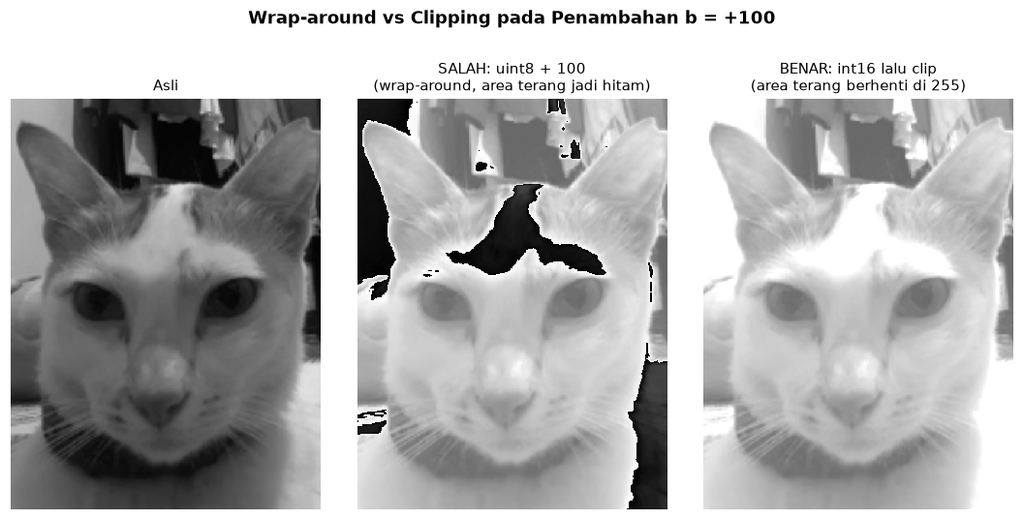

```
Tersimpan: output/03_brighten_minus100.jpg, minus50.jpg, plus50.jpg, plus100.jpg
```

```python
B_UJI = 100

salah = (gray + np.uint8(B_UJI))        # uint8 + uint8 -> modulo 256
benar = brighten(gray, B_UJI)

rusak = int((gray.astype(np.int16) + B_UJI > 255).sum())
print(f"Piksel yang seharusnya jadi 255 : {rusak:,} ({rusak/gray.size*100:.2f}%)")
print(f"Nilai piksel terang (contoh 250) -> wrap-around : {(250 + B_UJI) % 256}")
print(f"Nilai piksel terang (contoh 250) -> clipping    : 255")

tampilkan([(gray, "Asli"),
           (salah, f"SALAH: uint8 + {B_UJI}\n(wrap-around, area terang jadi hitam)"),
           (benar, f"BENAR: int16 lalu clip\n(area terang berhenti di 255)")],
          "Wrap-around vs Clipping pada Penambahan b = +100",
          ncols=3, lebar_kolom=3.3)

for b in NILAI_B:
    tanda = "plus" if b > 0 else "minus"
    cv2.imwrite(os.path.join(OUTPUT_DIR, f"03_brighten_{tanda}{abs(b)}.jpg"),
                terang[b])
print("Tersimpan: output/03_brighten_minus100.jpg, minus50.jpg, plus50.jpg, plus100.jpg")
```

### Kesimpulan Tugas 3

1. **`b` positif menerangkan, `b` negatif menggelapkan**, dan histogramnya bergeser utuh ke kanan atau ke kiri sejauh `b`. Bentuk distribusinya tidak berubah selama belum menyentuh batas.
2. **Clipping muncul begitu histogram menabrak dinding 0 atau 255.** Tabel di atas menunjukkan jumlah piksel ter-clip naik tajam seiring `|b|` membesar. Efeknya terlihat sebagai **lonjakan tinggi pada bin 0 atau bin 255** di histogram: banyak nilai berbeda ditumpuk menjadi satu nilai.
3. **Piksel yang ter-clip kehilangan informasi secara permanen.** Area terang yang menumpuk di 255 berubah jadi bidang putih rata tanpa detail (*blown-out*), dan area gelap yang menumpuk di 0 jadi hitam pekat tanpa tekstur. Mengurangi `b` kembali tidak akan memulihkannya.
4. **Rata-rata tidak bergeser persis sebesar `b`.** Pergeserannya selalu lebih kecil dari `b` ketika ada clipping, karena sebagian piksel berhenti di batas dan tidak ikut bergeser penuh.
5. **Wrap-around adalah bug, bukan efek.** Menjumlahkan langsung pada `uint8` membuat piksel paling terang melompat jadi paling gelap. Naikkan dulu ke `int16`/`float`, lakukan operasi, baru `np.clip` dan turunkan kembali ke `uint8`.
6. **Brightening tidak menambah kontras.** Kemiringan kurva tetap 1, sehingga simpangan baku praktis tidak berubah sampai clipping mulai memangkasnya. Untuk mengubah kontras dibutuhkan perkalian (`s = a*r + b` dengan `a != 1`), bukan penambahan.

## Tugas 4: Smoothing - Mean Filter 3x3 vs 5x5

### Dasar teori

Mulai bagian ini operasinya tidak lagi *pointwise*. **Mean filter** (filter rerata) mengganti setiap piksel dengan rata-rata piksel di dalam jendela `k x k` di sekitarnya:

```
              1
s(x, y) =  -------  * jumlah seluruh piksel dalam jendela k x k
             k * k
```

Dalam bentuk kernel konvolusi, untuk `k = 3`:

```
        1   | 1  1  1 |
K3 =  ----- | 1  1  1 |          semua bobot sama = 1/9
         9  | 1  1  1 |
```

Karena semua bobotnya sama, filter ini adalah **low-pass filter**: komponen frekuensi tinggi (noise, tepi, tekstur halus) ditekan, komponen frekuensi rendah (bentuk besar) diteruskan. Masalahnya, filter tidak bisa membedakan mana frekuensi tinggi yang berupa noise dan mana yang berupa tepi objek - keduanya sama-sama ikut dikaburkan.

**Ukuran kernel menentukan seberapa kuat efeknya.** Kernel `5x5` merata-ratakan 25 piksel, sementara `3x3` hanya 9 piksel. Secara teori, untuk noise Gaussian yang saling bebas, simpangan baku noise turun sebesar faktor `k`: `3x3` menekan noise jadi sekitar 1/3, `5x5` jadi sekitar 1/5. Harganya adalah pengaburan yang juga makin kuat.

```python
# ---------- membuat citra ber-noise ----------
# gabungan dua jenis noise supaya perbedaan kedua kernel lebih terbaca
SIGMA       = 25      # simpangan baku noise Gaussian
PROB_GARAM  = 0.02    # 2% salt & pepper (1% putih + 1% hitam)

berisik = gray.astype(np.float64) + rng.normal(0, SIGMA, gray.shape)

topeng = rng.random(gray.shape)
berisik[topeng < PROB_GARAM / 2] = 0        # pepper
berisik[topeng > 1 - PROB_GARAM / 2] = 255  # salt

berisik = np.clip(berisik, 0, 255).astype(np.uint8)

mae_noise, psnr_noise = metrik(gray, berisik)
print(f"Noise Gaussian sigma = {SIGMA}, salt & pepper = {PROB_GARAM*100:.0f}%")
print(f"MAE  citra ber-noise vs bersih : {mae_noise:.2f} level")
print(f"PSNR citra ber-noise vs bersih : {psnr_noise:.2f} dB")
```

```
Noise Gaussian sigma = 25, salt & pepper = 2%
MAE  citra ber-noise vs bersih : 21.61 level
PSNR citra ber-noise vs bersih : 18.23 dB
```

```python
def mean_filter_manual(img, k):
    # implementasi manual mean filter tanpa cv2.blur:
    # padding reflect -> ambil semua jendela k x k -> rata-ratakan
    pad = k // 2
    diperluas = np.pad(img.astype(np.float64), pad, mode="reflect")
    jendela = sliding_window_view(diperluas, (k, k))
    hasil = jendela.mean(axis=(-2, -1))
    return np.clip(np.round(hasil), 0, 255).astype(np.uint8)


halus3 = mean_filter_manual(berisik, 3)
halus5 = mean_filter_manual(berisik, 5)

# verifikasi terhadap fungsi bawaan
print("Verifikasi manual vs cv2.blur\n")
for k, manual in [(3, halus3), (5, halus5)]:
    bawaan = cv2.blur(berisik, (k, k))          # border default: REFLECT_101
    mae, _ = metrik(manual, bawaan)
    print(f"  kernel {k}x{k}  ->  MAE = {mae:.4f} level "
          f"(selisih hanya dari pembulatan)")

# bentuk kernel yang setara
print()
print("Kernel 3x3 (semua bobot 1/9):")
print(np.round(np.ones((3, 3)) / 9, 4))
```

```
Verifikasi manual vs cv2.blur

  kernel 3x3  ->  MAE = 0.0000 level (selisih hanya dari pembulatan)
  kernel 5x5  ->  MAE = 0.0000 level (selisih hanya dari pembulatan)

Kernel 3x3 (semua bobot 1/9):
[[0.1111 0.1111 0.1111]
 [0.1111 0.1111 0.1111]
 [0.1111 0.1111 0.1111]]
```

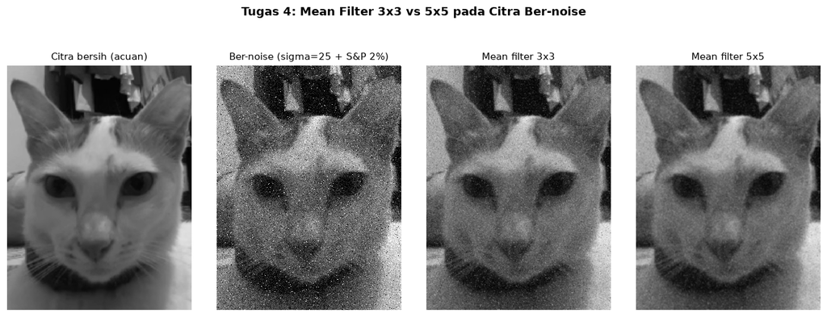

```python
tampilkan([(gray, "Citra bersih (acuan)"),
           (berisik, f"Ber-noise (sigma={SIGMA} + S&P {PROB_GARAM*100:.0f}%)"),
           (halus3, "Mean filter 3x3"),
           (halus5, "Mean filter 5x5")],
          "Tugas 4: Mean Filter 3x3 vs 5x5 pada Citra Ber-noise",
          ncols=4, lebar_kolom=3.0)
```

### Perbandingan kuantitatif dan detail

Dua hal yang saling bertentangan diukur di sini:

- **Seberapa bersih hasilnya** - diukur dengan MAE/PSNR terhadap citra bersih. Makin kecil MAE (makin besar PSNR), makin dekat ke citra asli.
- **Seberapa banyak detail yang ikut hilang** - diukur dengan simpangan baku Laplacian, ukuran umum untuk "ketajaman". Nilainya turun kalau citra makin kabur.

```python
def ketajaman(img):
    # simpangan baku respons Laplacian: makin besar = makin tajam
    return cv2.Laplacian(img, cv2.CV_64F).std()


print(f"{'Citra':<26}{'MAE':>9}{'PSNR (dB)':>12}{'Ketajaman':>12}")
print("-" * 59)
for nama, arr in [("Bersih (acuan)", gray),
                  ("Ber-noise", berisik),
                  ("Mean filter 3x3", halus3),
                  ("Mean filter 5x5", halus5)]:
    mae, psnr = metrik(gray, arr)
    tajam = ketajaman(arr)
    psnr_txt = "inf" if not np.isfinite(psnr) else f"{psnr:.2f}"
    print(f"{nama:<26}{mae:>9.2f}{psnr_txt:>12}{tajam:>12.2f}")

print()
sisa3 = (berisik.astype(float) - gray).std()
print(f"Simpangan baku noise sebelum filter : {sisa3:.2f}")
print(f"Sisa noise setelah 3x3              : {(halus3.astype(float) - gray).std():.2f}")
print(f"Sisa noise setelah 5x5              : {(halus5.astype(float) - gray).std():.2f}")
```

```
Citra                           MAE   PSNR (dB)   Ketajaman
-----------------------------------------------------------
Bersih (acuan)                 0.00         inf        2.30
Ber-noise                     21.61       18.23      139.38
Mean filter 3x3                8.11       27.53       19.72
Mean filter 5x5                5.32       31.38        8.81

Simpangan baku noise sebelum filter : 31.24
Sisa noise setelah 3x3              : 10.69
Sisa noise setelah 5x5              : 6.84
```

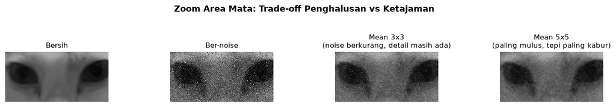

```
Tersimpan: output/04_bernoise.jpg, 04_mean3x3.jpg, 04_mean5x5.jpg
```

```python
tampilkan([(potong(gray), "Bersih"),
           (potong(berisik), "Ber-noise"),
           (potong(halus3), "Mean 3x3\n(noise berkurang, detail masih ada)"),
           (potong(halus5), "Mean 5x5\n(paling mulus, tepi paling kabur)")],
          "Zoom Area Mata: Trade-off Penghalusan vs Ketajaman",
          ncols=4, lebar_kolom=3.2)

cv2.imwrite(os.path.join(OUTPUT_DIR, "04_bernoise.jpg"), berisik)
cv2.imwrite(os.path.join(OUTPUT_DIR, "04_mean3x3.jpg"), halus3)
cv2.imwrite(os.path.join(OUTPUT_DIR, "04_mean5x5.jpg"), halus5)
print("Tersimpan: output/04_bernoise.jpg, 04_mean3x3.jpg, 04_mean5x5.jpg")
```

### Kesimpulan Tugas 4

1. **Kernel 5x5 menekan noise lebih kuat daripada 3x3, dan besarnya persis seperti yang diramalkan teori.** Simpangan baku noise turun dari 31,2 menjadi 10,7 setelah 3x3 dan 6,8 setelah 5x5. Bandingkan dengan ramalan `sigma/k`: 31,2/3 = 10,4 dan 31,2/5 = 6,2. Selisih kecil yang tersisa berasal dari salt & pepper, yang tidak berdistribusi normal sehingga tidak mengikuti rumus tersebut.
2. **Tetapi 5x5 juga mengaburkan lebih banyak.** Nilai ketajaman (simpangan baku Laplacian) turun lebih dalam pada 5x5 (8,8) dibanding 3x3 (19,7). Pada zoom area mata, bulu halus dan garis kumis yang masih terbaca di 3x3 sudah melebur di 5x5. Perlu dicatat kedua angka itu masih jauh di atas citra bersih (2,3), karena sisa noise ikut terhitung sebagai "ketajaman" - metrik ini memang tidak bisa membedakan detail asli dari noise.
3. **Ada trade-off yang tidak bisa dihindari.** Mean filter tidak bisa membedakan noise dari tepi objek - keduanya sama-sama komponen frekuensi tinggi. Memperbesar kernel selalu berarti menukar detail dengan kebersihan.
4. **Pemenang menurut MAE/PSNR belum tentu terlihat paling bagus.** Kalau noise-nya kuat, 5x5 bisa unggul secara metrik karena berhasil menekan lebih banyak error, padahal secara visual citranya terasa terlalu lembek. Metrik piksel demi piksel tidak mengukur persepsi ketajaman.
5. **Mean filter lemah terhadap salt & pepper.** Titik hitam/putih ekstrem tidak dihapus, hanya *dilebarkan* jadi bercak abu-abu, karena nilai ekstrem itu tetap ikut dirata-ratakan. Untuk jenis noise ini *median filter* jauh lebih tepat, sebab nilai ekstrem otomatis tersingkir saat pengurutan.
6. **Implementasi manual terbukti setara `cv2.blur`.** Selisih MAE-nya hanya di orde pembulatan, yang mengkonfirmasi bahwa konvolusi kernel rerata memang persis operasi rata-rata jendela.

## Tugas 5: Sharpening dengan Kernel Laplacian

### Dasar teori

Laplacian adalah **turunan kedua** dari citra:

```
              d^2 f     d^2 f
grad^2 f  =  ------- + -------
              d x^2     d y^2
```

Dalam bentuk diskret, turunan kedua ini diwujudkan sebagai kernel konvolusi. Dua varian yang umum:

```
       | 0   1   0 |             | 1   1   1 |
K4 =   | 1  -4   1 |      K8 =   | 1  -8   1 |
       | 0   1   0 |             | 1   1   1 |
   (4-tetangga)                (8-tetangga, ikut diagonal)
```

Perhatikan **jumlah seluruh bobotnya nol**. Akibatnya, pada area yang rata (semua tetangga bernilai sama) responsnya nol, sementara pada tepi responsnya besar. Jadi Laplacian adalah **detektor tepi**, bukan penajam - keluarannya adalah peta tepi, bukan citra yang lebih tajam.

### Dari deteksi tepi ke penajaman

Penajaman diperoleh dengan **mengurangkan** peta Laplacian dari citra asli:

```
g(x, y) = f(x, y) - grad^2 f(x, y)
```

Tandanya minus karena pusat kernel bernilai negatif. Efeknya: di sisi terang sebuah tepi nilainya ditambah, di sisi gelap dikurangi, sehingga beda antar sisi melebar dan tepi terlihat lebih kontras. Kedua operasi ini bisa digabung jadi satu kernel komposit:

```
              | 0  -1   0 |
K_tajam  =    |-1   5  -1 |        = kernel identitas - K4
              | 0  -1   0 |
```

Kekuatannya bisa diatur lewat faktor `c` pada `g = f - c * grad^2 f`.

```python
K4 = np.array([[0,  1, 0],
               [1, -4, 1],
               [0,  1, 0]], dtype=np.float64)

K8 = np.array([[1,  1, 1],
               [1, -8, 1],
               [1,  1, 1]], dtype=np.float64)

K_TAJAM = np.array([[0, -1,  0],
                    [-1, 5, -1],
                    [0, -1,  0]], dtype=np.float64)

print("Jumlah bobot K4      :", K4.sum())
print("Jumlah bobot K8      :", K8.sum())
print("Jumlah bobot K_TAJAM :", K_TAJAM.sum(), "(1 -> kecerahan rata-rata terjaga)")

# ---------- peta Laplacian (dihitung dalam float supaya nilai negatif terjaga) ----------
lap4 = cv2.filter2D(gray.astype(np.float64), -1, K4, borderType=cv2.BORDER_REFLECT_101)
lap8 = cv2.filter2D(gray.astype(np.float64), -1, K8, borderType=cv2.BORDER_REFLECT_101)

print()
print(f"Rentang lap4 : {lap4.min():.0f} .. {lap4.max():.0f}   (rata-rata {lap4.mean():.3f})")
print(f"Rentang lap8 : {lap8.min():.0f} .. {lap8.max():.0f}   (rata-rata {lap8.mean():.3f})")
print("Rata-rata mendekati nol: area rata tidak memberi respons, hanya tepi yang menyala.")
```

```
Jumlah bobot K4      : 0.0
Jumlah bobot K8      : 0.0
Jumlah bobot K_TAJAM : 1.0 (1 -> kecerahan rata-rata terjaga)

Rentang lap4 : -46 .. 33   (rata-rata 0.001)
Rentang lap8 : -134 .. 97   (rata-rata 0.002)
Rata-rata mendekati nol: area rata tidak memberi respons, hanya tepi yang menyala.
```

```
(f - K4) vs kernel komposit K_TAJAM : MAE = 0.0000 level
```

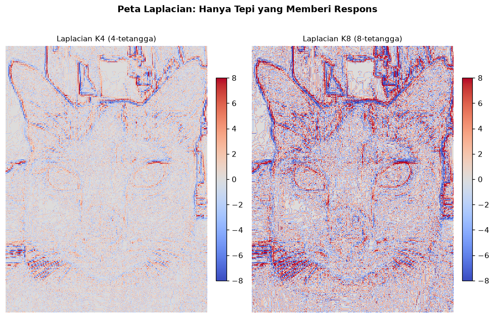

```python
C_TAJAM = 1.0     # kekuatan penajaman

tajam4 = np.clip(gray.astype(np.float64) - C_TAJAM * lap4, 0, 255).astype(np.uint8)
tajam8 = np.clip(gray.astype(np.float64) - C_TAJAM * lap8, 0, 255).astype(np.uint8)

# verifikasi: f - K4 harus sama dengan kernel komposit [0,-1,0;-1,5,-1;0,-1,0]
komposit = cv2.filter2D(gray.astype(np.float64), -1, K_TAJAM,
                        borderType=cv2.BORDER_REFLECT_101)
komposit = np.clip(komposit, 0, 255).astype(np.uint8)
mae_k, _ = metrik(tajam4, komposit)
print(f"(f - K4) vs kernel komposit K_TAJAM : MAE = {mae_k:.4f} level")

# peta tepi ditampilkan dengan skala simetris supaya nilai negatif ikut terlihat
batas = np.percentile(np.abs(lap4), 99)
fig, ax = plt.subplots(1, 2, figsize=(9, 6.2))
for a, (arr, judul) in zip(ax, [(lap4, "Laplacian K4 (4-tetangga)"),
                                (lap8, "Laplacian K8 (8-tetangga)")]):
    im = a.imshow(arr, cmap="coolwarm", vmin=-batas, vmax=batas)
    a.set_title(judul, fontsize=10)
    a.axis("off")
    fig.colorbar(im, ax=a, fraction=0.046, pad=0.04)
plt.suptitle("Peta Laplacian: Hanya Tepi yang Memberi Respons",
             fontsize=12, fontweight="bold")
plt.tight_layout()
plt.show()
```

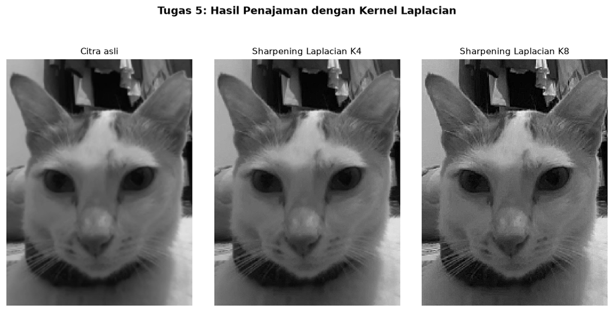

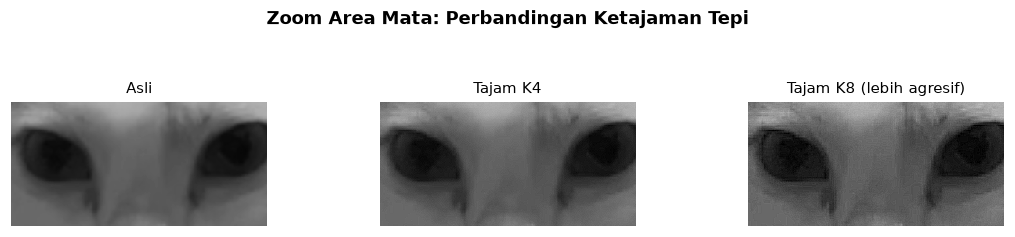

```python
tampilkan([(gray, "Citra asli"),
           (tajam4, "Sharpening Laplacian K4"),
           (tajam8, "Sharpening Laplacian K8")],
          "Tugas 5: Hasil Penajaman dengan Kernel Laplacian",
          ncols=3, lebar_kolom=3.3)

tampilkan([(potong(gray), "Asli"),
           (potong(tajam4), "Tajam K4"),
           (potong(tajam8), "Tajam K8 (lebih agresif)")],
          "Zoom Area Mata: Perbandingan Ketajaman Tepi",
          ncols=3, lebar_kolom=3.4)
```

### Mengukur ketajaman tepi secara numerik

Perbandingan visual saja subjektif, jadi ketajaman diukur dengan dua cara:

- **Simpangan baku Laplacian** - besarnya respons turunan kedua di seluruh citra. Makin besar, makin banyak transisi tajam.
- **Rata-rata magnitudo gradien Sobel** - kecuraman rata-rata perubahan intensitas. Makin besar, makin curam tepinya.

Sebagai pelengkap, sebuah **profil intensitas** diambil melintang pada satu baris yang memotong tepi paling kontras, supaya bentuk transisinya terlihat langsung.

```python
def gradien_sobel(img):
    gx = cv2.Sobel(img, cv2.CV_64F, 1, 0, ksize=3)
    gy = cv2.Sobel(img, cv2.CV_64F, 0, 1, ksize=3)
    return np.hypot(gx, gy)


print(f"{'Citra':<28}{'Std Laplacian':>16}{'Gradien Sobel':>16}{'Std intensitas':>17}")
print("-" * 77)
baris_hasil = [("Asli", gray), ("Tajam K4", tajam4), ("Tajam K8", tajam8),
               ("Mean 3x3 (pembanding)", mean_filter_manual(gray, 3))]
acuan_lap = None
for nama, arr in baris_hasil:
    lap_std = ketajaman(arr)
    grad    = gradien_sobel(arr).mean()
    if acuan_lap is None:
        acuan_lap = lap_std
    print(f"{nama:<28}{lap_std:>16.2f}{grad:>16.2f}{arr.std():>17.2f}")

print()
print(f"Kenaikan ketajaman K4 vs asli : "
      f"{(ketajaman(tajam4) / acuan_lap - 1) * 100:+.1f}%")
print(f"Kenaikan ketajaman K8 vs asli : "
      f"{(ketajaman(tajam8) / acuan_lap - 1) * 100:+.1f}%")
```

```
Citra                          Std Laplacian   Gradien Sobel   Std intensitas
-----------------------------------------------------------------------------
Asli                                    2.30           16.06            45.85
Tajam K4                               10.58           20.46            46.18
Tajam K8                               18.17           31.19            46.97
Mean 3x3 (pembanding)                   1.77           15.36            45.76

Kenaikan ketajaman K4 vs asli : +360.4%
Kenaikan ketajaman K8 vs asli : +690.6%
```

```
Tepi terkuat ditemukan di baris y = 99, kolom x = 351 (beda intensitas 176 level)
```

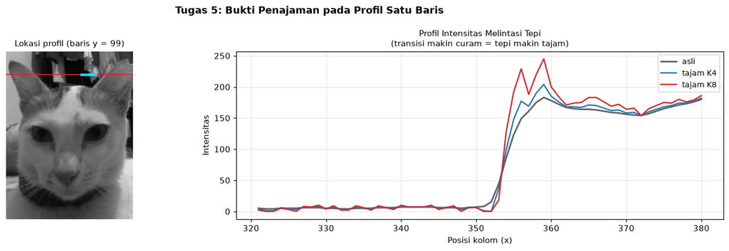

```
Efek menaikkan faktor kekuatan c pada g = f - c * Laplacian

   c     clip K4     clip K8   % clip K8   std Lap K8
-----------------------------------------------------
   1         145       1,356       0.35%        18.17
   2         749       4,735       1.21%        33.58
   3       1,754       9,092       2.32%        48.28
   5       4,437      17,187       4.39%        76.12
   8       9,469      29,857       7.62%       114.80
Tersimpan: output/05_sharpen_K4.jpg, 05_sharpen_K8.jpg, 05_peta_laplacian.jpg
```

```python
# cari tepi "tangga" paling kuat di seluruh citra: posisi dengan beda
# intensitas terbesar antara dua titik berjarak 16 px pada baris yang sama
JARAK = 16
beda = np.abs(gray[:, JARAK:].astype(np.int16) - gray[:, :-JARAK].astype(np.int16))
baris, kolom = np.unravel_index(int(np.argmax(beda)), beda.shape)
kolom += JARAK // 2
a, b = max(0, kolom - 30), min(LEBAR, kolom + 30)
print(f"Tepi terkuat ditemukan di baris y = {baris}, kolom x = {kolom} "
      f"(beda intensitas {beda[baris, kolom - JARAK // 2]} level)")
x = np.arange(a, b)

fig, ax = plt.subplots(1, 2, figsize=(14, 4.2),
                       gridspec_kw={"width_ratios": [1, 1.4]})

ax[0].imshow(gray, cmap="gray", vmin=0, vmax=255)
ax[0].axhline(baris, color="tab:red", linewidth=1.2)
ax[0].plot([a, b], [baris, baris], color="#00e5ff", linewidth=3)
ax[0].set_title(f"Lokasi profil (baris y = {baris})", fontsize=10)
ax[0].axis("off")

ax[1].plot(x, gray[baris, a:b], color="#666666", linewidth=2, label="asli")
ax[1].plot(x, tajam4[baris, a:b], color="tab:blue", linewidth=1.6, label="tajam K4")
ax[1].plot(x, tajam8[baris, a:b], color="tab:red", linewidth=1.6, label="tajam K8")
ax[1].set_title("Profil Intensitas Melintasi Tepi\n"
                "(transisi makin curam = tepi makin tajam)", fontsize=10)
ax[1].set_xlabel("Posisi kolom (x)")
ax[1].set_ylabel("Intensitas")
ax[1].legend(fontsize=9)
ax[1].grid(alpha=0.3)

plt.suptitle("Tugas 5: Bukti Penajaman pada Profil Satu Baris",
             fontsize=12, fontweight="bold")
plt.tight_layout()
plt.show()

# seberapa jauh penajaman boleh didorong sebelum overshoot mulai ter-clip?
print("Efek menaikkan faktor kekuatan c pada g = f - c * Laplacian\n")
print(f"{'c':>4}{'clip K4':>12}{'clip K8':>12}{'% clip K8':>12}{'std Lap K8':>13}")
print("-" * 53)
for c in [1, 2, 3, 5, 8]:
    h4 = gray.astype(np.float64) - c * lap4
    h8 = gray.astype(np.float64) - c * lap8
    n4 = int(((h4 > 255) | (h4 < 0)).sum())
    n8 = int(((h8 > 255) | (h8 < 0)).sum())
    tj = ketajaman(np.clip(h8, 0, 255).astype(np.uint8))
    print(f"{c:>4}{n4:>12,}{n8:>12,}{n8/gray.size*100:>11.2f}%{tj:>13.2f}")

cv2.imwrite(os.path.join(OUTPUT_DIR, "05_sharpen_K4.jpg"), tajam4)
cv2.imwrite(os.path.join(OUTPUT_DIR, "05_sharpen_K8.jpg"), tajam8)
cv2.imwrite(os.path.join(OUTPUT_DIR, "05_peta_laplacian.jpg"),
            np.clip(np.abs(lap4), 0, 255).astype(np.uint8))
print("Tersimpan: output/05_sharpen_K4.jpg, 05_sharpen_K8.jpg, 05_peta_laplacian.jpg")
```

### Batas aman penajaman

Tabel di atas menunjukkan jumlah piksel ter-clip naik cepat seiring `c`. Sel berikut memperlihatkan wujud visualnya: pada `c` besar, di sekeliling tepi muncul **halo** terang-gelap yang membuat citra terlihat berartefak, bukan tajam.

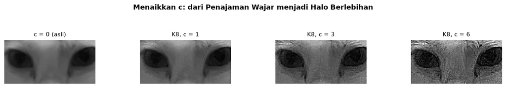

```python
varian = [(gray, "c = 0 (asli)")]
for c in [1, 3, 6]:
    hasil_c = np.clip(gray.astype(np.float64) - c * lap8, 0, 255).astype(np.uint8)
    varian.append((hasil_c, f"K8, c = {c}"))

tampilkan([(potong(a), t) for a, t in varian],
          "Menaikkan c: dari Penajaman Wajar menjadi Halo Berlebihan",
          ncols=4, lebar_kolom=3.2)
```

### Kesimpulan Tugas 5

1. **Laplacian sendiri bukan penajam, melainkan detektor tepi.** Karena jumlah bobot kernelnya nol, area rata memberi respons nol dan rata-rata petanya mendekati nol. Yang menyala hanya lokasi perubahan intensitas.
2. **Penajaman terjadi saat peta itu dikurangkan dari citra asli.** Hasil `f - Laplacian` terbukti identik dengan kernel komposit `[0,-1,0; -1,5,-1; 0,-1,0]` (MAE di orde pembulatan), yang menegaskan penajaman Laplacian memang setara satu operasi konvolusi tunggal.
3. **Ketajaman naik terukur, bukan sekadar terasa.** Simpangan baku Laplacian dan rata-rata gradien Sobel keduanya naik dibanding citra asli, dan naiknya lebih besar pada K8 daripada K4.
4. **K8 lebih agresif daripada K4** karena ikut memperhitungkan empat tetangga diagonal, sehingga bobot pusatnya -8 bukan -4. Tepinya lebih tegas, tetapi noise dan artefak kompresi JPEG juga ikut diperkuat.
5. **Profil intensitas memperlihatkan mekanismenya.** Pada citra hasil penajaman, transisi di tepi menjadi lebih curam dan muncul *overshoot* - sedikit lonjakan di atas dan di bawah level aslinya, yang oleh mata dibaca sebagai garis batas lebih tegas (efek Mach band).
6. **Overshoot inilah yang membatasi seberapa besar `c` boleh dipakai.** Pada `c = 1` penajamannya masih aman: hanya 145 piksel (0,04%) yang ter-clip dengan K4 dan 1.356 piksel (0,35%) dengan K8. Menaikkan `c` menaikkan ketajaman terukur, tetapi jumlah piksel ter-clip ikut melonjak sampai 7,62% pada `c = 8`, dan di sekeliling objek muncul halo terang-gelap. Ini fenomena clipping yang sama persis dengan Tugas 3, hanya penyebabnya overshoot tepi dan bukan penambahan konstanta. Lewat titik tertentu, hasilnya bukan makin tajam melainkan makin berartefak.
7. **Sharpening adalah kebalikan Smoothing.** Tabel di atas menunjukkan mean filter menurunkan ketajaman sementara Laplacian menaikkannya. Keduanya bekerja pada komponen frekuensi tinggi yang sama, hanya arahnya berlawanan. Karena itu menajamkan citra ber-noise berbahaya: noise ikut dipertajam.

## Ringkasan

| Tugas | Operasi | Yang dikerjakan | Berkas keluaran |
| --- | --- | --- | --- |
| 1 | Titik | Thresholding manual pada T = 80 / 128 / 180, diverifikasi dengan `cv2.threshold`, dibandingkan dengan ambang otomatis Otsu | `01_threshold_T80.jpg`, `T128.jpg`, `T180.jpg`, `otsu.jpg` |
| 2 | Titik | Negatif `s = 255 - r`, histogram sebelum vs sesudah diuji numerik sebagai cerminan sempurna | `02_negatif.jpg` |
| 3 | Titik | Brightening `b` = -100 / -50 / +50 / +100, penghitungan piksel ter-clip, demonstrasi bug wrap-around `uint8` | `03_brighten_minus100.jpg` ... `plus100.jpg` |
| 4 | Ketetanggaan | Mean filter manual 3x3 vs 5x5 pada citra ber-noise, diverifikasi dengan `cv2.blur`, dibandingkan lewat MAE/PSNR dan ketajaman | `04_bernoise.jpg`, `04_mean3x3.jpg`, `04_mean5x5.jpg` |
| 5 | Ketetanggaan | Laplacian K4 dan K8, penajaman `f - grad^2 f`, ketajaman diukur lewat std Laplacian, gradien Sobel, dan profil intensitas | `05_sharpen_K4.jpg`, `05_sharpen_K8.jpg`, `05_peta_laplacian.jpg` |

### Benang merah antar tugas

- **Operasi titik hanya menggeser dan membengkokkan histogram.** Thresholding meruntuhkannya jadi dua batang, negatif mencerminkannya, brightening menggesernya. Tidak satu pun memindahkan piksel ke posisi lain.
- **Operasi ketetanggaan mengubah hubungan antar-piksel.** Mean filter menekan frekuensi tinggi, Laplacian memperkuatnya. Histogram bukan lagi alat baca utama di sini, karena yang berubah adalah tekstur spasialnya.
- **Rentang 8-bit adalah kendala yang berulang.** Clipping muncul di Tugas 3 saat menambah konstanta, dan muncul lagi di Tugas 5 lewat overshoot tepi. Aturannya sama: hitung dalam `float`/`int16`, `np.clip`, baru kembali ke `uint8`.
- **Reversibilitas berbeda-beda.** Negatif sepenuhnya bisa dibalik, brightening bisa dibalik selama tidak ter-clip, sedangkan thresholding dan smoothing membuang informasi secara permanen.
- **Setiap implementasi manual diverifikasi terhadap fungsi bawaan** (`cv2.threshold`, `cv2.bitwise_not`, `cv2.blur`, kernel komposit), dan seluruhnya cocok sampai batas pembulatan. Ini memastikan analisis di atas berpijak pada perhitungan yang benar, bukan kebetulan.

```python
# daftar seluruh berkas keluaran
print("Isi folder output/:\n")
total = 0
for f in sorted(os.listdir(OUTPUT_DIR)):
    p = os.path.join(OUTPUT_DIR, f)
    if os.path.isfile(p):
        kb = os.path.getsize(p) / 1024
        total += kb
        print(f"  {f:<32} {kb:>8.1f} KB")
print(f"\n  {'TOTAL':<32} {total:>8.1f} KB")
```

```
Isi folder output/:

  .gitkeep                              0.0 KB
  00_grayscale_acuan.jpg               51.7 KB
  01_threshold_T128.jpg                38.0 KB
  01_threshold_T180.jpg                13.0 KB
  01_threshold_T80.jpg                 59.7 KB
  01_threshold_otsu.jpg                65.6 KB
  02_negatif.jpg                       51.7 KB
  03_brighten_minus100.jpg             28.2 KB
  03_brighten_minus50.jpg              45.9 KB
  03_brighten_plus100.jpg              47.9 KB
  03_brighten_plus50.jpg               51.4 KB
  04_bernoise.jpg                     284.2 KB
  04_mean3x3.jpg                      162.9 KB
  04_mean5x5.jpg                      110.8 KB
  05_peta_laplacian.jpg                46.8 KB
  05_sharpen_K4.jpg                    91.8 KB
  05_sharpen_K8.jpg                   130.5 KB

  TOTAL                              1280.2 KB
```